# Fed Policy, the Dual Mandate, and Treasury Yield Responses

# 15. Graphic 3: Yield responses by maturity

The final figure compares the magnitude of one-day changes across maturities. Each point is one announcement; the box summarizes the distribution across all announcements.

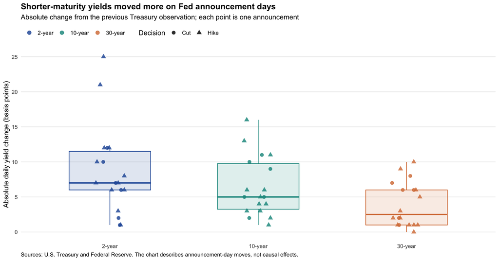

```r
response_plot <- ggplot(
  event_moves,
  aes(tenor, absolute_change_bp, colour = tenor)
) +
  geom_boxplot(aes(fill = tenor), width = 0.55, alpha = 0.14,
               outlier.shape = NA, show.legend = FALSE) +
  geom_point(
    aes(shape = decision),
    position = position_jitter(width = 0.10, height = 0, seed = 6400),
    size = 2.7, alpha = 0.82
  ) +
  scale_colour_manual(values = c("#2459A6", "#15958C", "#D77C43")) +
  scale_fill_manual(values = c("#2459A6", "#15958C", "#D77C43")) +
  labs(
    title = "Shorter-maturity yields moved more on Fed announcement days",
    subtitle = "Absolute change from the previous Treasury observation; each point is one announcement",
    x = NULL, y = "Absolute daily yield change (basis points)", colour = NULL,
    shape = "Decision",
    caption = paste0(
      "Sources: U.S. Treasury and Federal Reserve. ",
      "The chart describes announcement-day moves, not causal effects."
    )
  ) +
  theme_minimal(base_size = 12) +
  theme(
    legend.position = "top", legend.justification = "left",
    panel.grid.minor = element_blank(), panel.grid.major.x = element_blank(),
    plot.title = element_text(face = "bold"),
    plot.caption = element_text(hjust = 0)
  )

ggsave(file.path(result_dir, "announcement_day_yield_changes.png"), response_plot,
       width = 14, height = 6.8, dpi = 160, bg = "white")
if (knitr::is_html_output()) print(response_plot)
```

The maturity comparison is much clearer in changes than in levels. Across 18 announcements, the median absolute moves were 7.0, 5.0, and 2.5 basis points. The declining pattern shows that announcement-day yield repricing was concentrated at the front end of the curve.

# 16. Save the results and their sources

Save the cleaned datasets, figures, source register, and file fingerprints needed to reproduce the analysis.

```r
write.csv(daily, file.path(result_dir, "daily_yields_with_events.csv"), row.names = FALSE, na = "")
write.csv(events, file.path(result_dir, "policy_events_rvest.csv"), row.names = FALSE, na = "")
write.csv(macro, file.path(result_dir, "macro_conditions.csv"), row.names = FALSE, na = "")
write.csv(event_moves, file.path(result_dir, "announcement_day_yield_changes.csv"),
          row.names = FALSE, na = "")
write.csv(response_summary, file.path(result_dir, "yield_response_summary.csv"), row.names = FALSE)
data_checks <- bind_rows(
  yield_checks |> mutate(dataset = "Daily Treasury yields", .before = 1),
  macro_checks |> mutate(dataset = "Monthly macro indicators", .before = 1)
)
write.csv(data_checks, file.path(result_dir, "data_checks.csv"), row.names = FALSE)
source_register <- bind_rows(source_log)
write.csv(source_register, file.path(result_dir, "source_log.csv"), row.names = FALSE)

# Fingerprint the outputs, allowing later changes to be detected.
output_files <- c(
  "daily_yields_with_events.csv", "policy_events_rvest.csv",
  "macro_conditions.csv", "announcement_day_yield_changes.csv",
  "yield_response_summary.csv", "daily_yields_with_events.png",
  "inflation_unemployment_with_events.png", "announcement_day_yield_changes.png",
  "data_checks.csv", "source_log.csv"
)
output_manifest <- tibble(
  file = paste0("results/", output_files),
  sha256 = vapply(file.path(result_dir, output_files), function(path) {
    digest::digest(file = path, algo = "sha256")
  }, character(1))
)
write.csv(output_manifest, file.path(result_dir, "output_manifest.csv"), row.names = FALSE)
writeLines(capture.output(sessionInfo()), file.path(result_dir, "session_info.txt"))

knitr::kable(tibble(
  check = c("Daily yield observations", "Monthly macro observations",
            "Policy changes", "Source documents"),
  result = c(nrow(yields), nrow(macro), nrow(events), nrow(source_register))
))
```

| check | result |
| --- | --- |
| Daily yield observations | 1178 |
| Monthly macro observations | 56 |
| Policy changes | 18 |
| Source documents | 26 |

# What the evidence means

`read_html()` reads each public document, `html_table()` extracts structured tables, and `html_elements()` with `html_text2()` extracts named XML fields and announcement text. The resulting datasets connect monthly macroeconomic conditions, daily Treasury yields, and verified policy dates.

The evidence does not support the claim that every hike immediately lowers inflation or that every cut immediately strengthens employment. The decisions are cumulative, their effects arrive with a lag, and markets often anticipate them. The stronger conclusion is that inflation declined during the restrictive phase without a contemporaneous surge in unemployment, while Treasury repricing was most pronounced at shorter maturities.

Investors should not treat a hike or cut as an automatic signal for all Treasury maturities. The 2-year yield was the most sensitive to announcement-day repricing, so front-end exposure requires particular attention to incoming inflation, employment, and policy-expectation data. Longer yields moved less on these announcement days, but long-duration bond prices remain highly sensitive to each basis-point move. Maturity choice should therefore reflect both expected policy surprises and price duration, rather than the direction of the announced rate change alone.